# 16. The effective reproduction number R_t over time

ReproductiveNumbers.jl vignettes

Author

Simon D. W. Frost

Published

September 18, 2026

## Overview

`R₀` describes the infection-free population. Once an epidemic is under way, the expected number of new infections caused by an infectious individual falls as susceptibles are used up and, in models with reinfection, changes as recovered individuals accumulate. The *effective reproduction number* `R_t` is the next-generation construction linearised at the current state rather than at the infection-free steady state. Because the state enters `T` only through the uninfected compartments, `R_t` has a closed form whenever `R₀` does, and it can be evaluated at any state, along a solution, or returned by the solver as an observed variable.

Two other quantities are also called `R_t` in the literature: the *case* reproduction number estimated from incidence data through a renewal equation, which averages over the infectious period, and growth-rate based estimates. What the package computes is the instantaneous reproduction number of the mechanistic model, the threshold for growth of the linearised infected subsystem at each instant.

## SIR: `R_t = R₀ S(t)/N`

```julia
using ReproductiveNumbers, ModelingToolkit, Symbolics, OrdinaryDiffEqTsit5, Plots
using ModelingToolkit: t_nounits as t, D_nounits as D

@parameters β γ N
@variables S(t) I(t) R(t)
sir = complete(System(
    [D(S) ~ -β * S * I / N, D(I) ~ β * S * I / N - γ * I, D(R) ~ γ * I], t; name = :sir))
Rt = effective_reproduction_number(sir, [I])
```

```
(S(t)*β) / (N*γ)
```

The same expression is obtained from a next-generation matrix built with the uninfected states left symbolic (`equilibrium = Dict()`), which also lets us evaluate it at any state:

```julia
ngm = next_generation_matrix(sir, [I]; equilibrium = Dict())
(effective_reproduction_number(ngm, Dict(S => N / 2)),
    effective_reproduction_number(ngm, [S => 500.0, β => 0.5, γ => 0.25, N => 1000.0]))
```

```
(((1//2)*β) / γ, 1.0)
```

## A trajectory from the solver

`add_effective_reproduction_number` returns a copy of the system with `Rt(t)` as an observed variable, so the solver computes it along with the state:

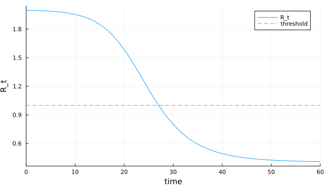

```julia
sir_Rt, Rtvar = add_effective_reproduction_number(sir, [I])
prob = ODEProblem(
    sir_Rt, [S => 999.0, I => 1.0, R => 0.0, β => 0.5, γ => 0.25, N => 1000.0], (0.0, 60.0))
sol = solve(prob, Tsit5(); saveat = 1.0)
plot(sol; idxs = [Rtvar], label = "R_t", xlabel = "time", ylabel = "R_t")
hline!([1.0]; label = "threshold", linestyle = :dash)
```

The peak of the epidemic is where `R_t` crosses one:

```julia
tpeak = sol.t[argmax(sol[I])]
(tpeak, sol(tpeak; idxs = Rtvar))
```

```
(27.0, 1.002195426001892)
```

Evaluating along an existing solution gives the same numbers without rebuilding the system (useful when there is no closed form, since the numeric spectral radius is used):

```julia
maximum(abs, effective_reproduction_number(ngm, sol) .- sol[Rtvar])
```

```
0.0
```

## Reinfection: `R_t` depends on more than `S`

In an SEIRS model in which recovered individuals are reinfected with reduced susceptibility `σ`, the effective reproduction number counts both routes:

```julia
@parameters βs σ κ γs μ ω Ns
@variables Ss(t) E(t) Is(t) Rs(t)
λ = βs * Is / Ns
seirs = complete(System(
    [D(Ss) ~ μ * Ns + ω * Rs - λ * Ss - μ * Ss,
        D(E) ~ λ * Ss + σ * λ * Rs - (κ + μ) * E,
        D(Is) ~ κ * E - (γs + μ) * Is,
        D(Rs) ~ γs * Is - σ * λ * Rs - ω * Rs - μ * Rs],
    t;
    name = :seirs))
effective_reproduction_number(seirs, [E, Is])
```

```
((Ss(t)*βs + Rs(t)*βs*σ)*κ) / (Ns*(γs + μ)*(κ + μ))
```

The endemic equilibrium is where `R_t = 1`; approaching it, `R_t` oscillates around one:

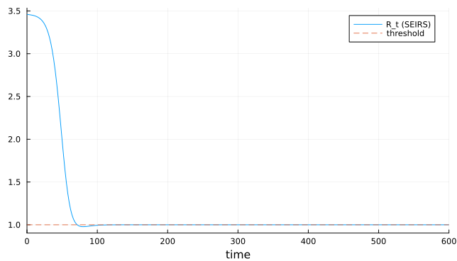

```julia
seirs_Rt, Rtvar2 = add_effective_reproduction_number(seirs, [E, Is])
p = [βs => 0.4, σ => 0.5, κ => 0.2, γs => 0.1, μ => 0.01, ω => 0.02, Ns => 1000.0]
prob2 = ODEProblem(
    seirs_Rt, [[Ss => 999.0, E => 0.0, Is => 1.0, Rs => 0.0]; p], (0.0, 600.0))
sol2 = solve(prob2, Tsit5(); saveat = 2.0)
plot(sol2; idxs = [Rtvar2], label = "R_t (SEIRS)", xlabel = "time")
hline!([1.0]; label = "threshold", linestyle = :dash)
```

```julia
sol2[Rtvar2][end]
```

```
1.0000281006219403
```

## Vector-borne infection: two susceptible pools

For the Ross–Macdonald model of vignette 4 the effective reproduction number involves both the susceptible humans and the susceptible mosquitoes:

```julia
@parameters a b c γₕ μᵥ N_H N_V
@variables S_H(t) I_H(t) S_V(t) I_V(t)
malaria = complete(System(
    [D(S_H) ~ -a * b * S_H * I_V / N_H + γₕ * I_H,
        D(I_H) ~ a * b * S_H * I_V / N_H - γₕ * I_H,
        D(S_V) ~ μᵥ * N_V - a * c * S_V * I_H / N_H - μᵥ * S_V,
        D(I_V) ~ a * c * S_V * I_H / N_H - μᵥ * I_V],
    t;
    name = :malaria))
effective_reproduction_number(malaria, [I_H, I_V])
```

```
sqrt((S_H(t)*S_V(t)*(a^2)*b*c) / ((N_H^2)*γₕ*μᵥ))
```